# Mapas en acción. Analítica avanzada

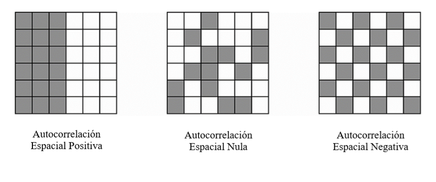

¿Cómo ver si una fuerza tiene patrones espaciales?

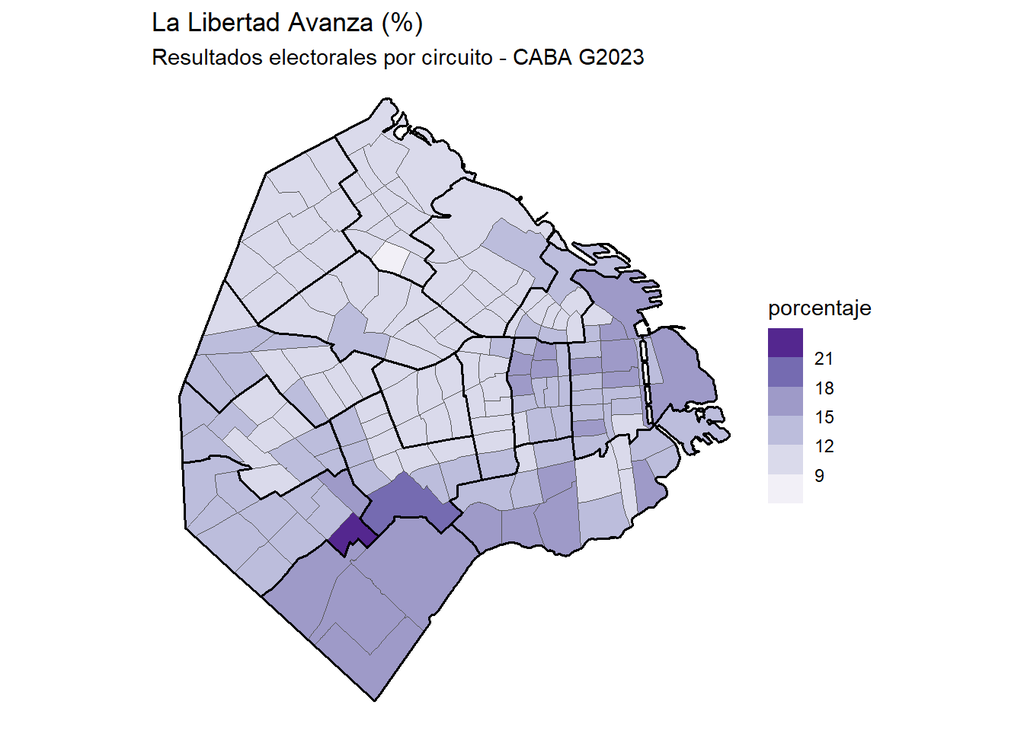

```r
gdf %>%
  filter(partido == "la libertad avanza") %>%
  ggplot()+
  geom_sf(aes(fill=porcentaje)) +
  geom_sf(data=sec, color="black", fill=NaN, linewidth=.7)+
  scale_fill_fermenter(palette = "Purples", direction = 1)+
  labs(title="La Libertad Avanza (%)",
       subtitle="Resultados electorales por circuito - CABA G2023")+
  theme_void()
```

La definición clave es: ¿con qué relacionamos cada unidad? Con sus **vecinos**.

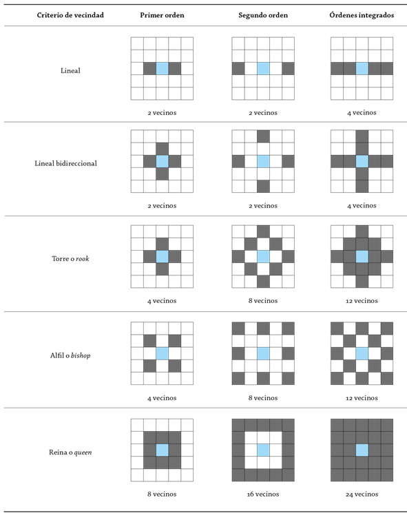

Trabajaremos en formato *wide* para que sea más cómoda de manipular la base de datos.

```r
partidos <- c("la libertad avanza", "union por la patria", "juntos por el cambio")
gdf_w <- gdf %>%
  st_drop_geometry() %>%
  filter(partido %in% partidos) %>%
  pivot_wider(id_cols="circuito", names_from="partido", values_from="porcentaje") %>%
  left_join(cir_clean, by=c("circuito"="CIRCUITO_N")) %>%
  st_as_sf()


vecinos <- poly2nb(gdf_w, row.names = gdf_w$circuito, queen = T)
pesos <- nb2listw(vecinos, style="minmax", zero.policy=T)
serie_lla <- gdf_w$`la libertad avanza`
ids <- gdf_w$circuito

class(vecinos)
```

```
[1] "nb"
```

```r
vecinos[1:2]
```

```
[[1]]
[1]  2  3 16 50 54

[[2]]
[1]  1  3 15 16
```

```r
#View(vecinos)
```

Veamoslo gráficamente.

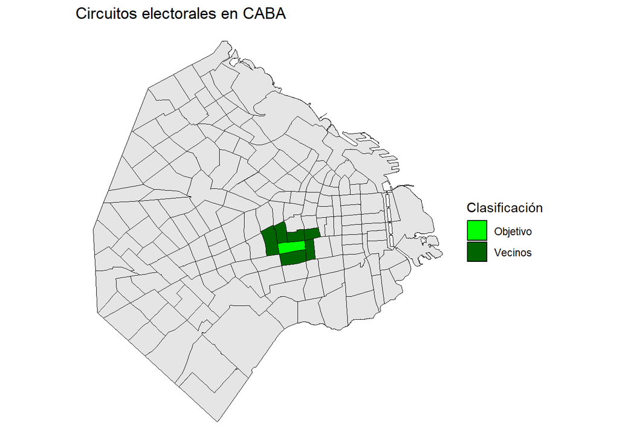

```r
circuito_objetivo <- 60

ggplot()+
  geom_sf(data=cir, color="black")+
  geom_sf(data=filter(cir, CIRCUITO_N==circuito_objetivo), aes(fill="Objetivo"), color="black")+
  geom_sf(data=filter(cir, CIRCUITO_N %in% vecinos[circuito_objetivo][[1]]), aes(fill="Vecinos"), color="black")+
  scale_fill_manual(name = "Clasificación",  values = c("Objetivo" = "green","Vecinos" = "darkgreen"))+
  labs(title="Circuitos electorales en CABA")+
  theme_void()
```

## 4.4. Medida global: índice I de Moran

El índice I de Moran es una medida clásica de autocorrelación espacial que permite evaluar en qué medida los valores de una variable se agrupan en el espacio. Este indicador toma valores entre –1 y 1. Los valores positivos indican una autocorrelación espacial positiva —áreas con valores similares tienden a agruparse—, mientras que los valores negativos reflejan una autocorrelación negativa, donde unidades con valores altos suelen estar rodeadas de unidades con valores bajos (y viceversa). Un valor cercano a cero sugiere ausencia de patrón espacial, es decir, una distribución aleatoria.

El análisis del índice de Moran global ofrece una visión sintética del grado de dependencia espacial en la región analizada, funcionando como una “correlación espacial” general. Se complementa con el cálculo del valor p que indica si la autocorrelación observada es estadísticamente significativa o podría explicarse por azar.

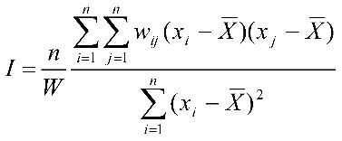

Calculemos el índice para nuestra serie.

```r
i_moran <- moran(serie_lla, # serie
                 n = length(vecinos), # cantidad de zonas
                 listw = pesos, # pesos
                 S0 = Szero(pesos) #suma de los pesos
                 )[[1]]

paste0("I Moran de LLA: ",round(i_moran,3))
```

```
[1] "I Moran de LLA: 0.632"
```

Confirmamos significancia estadística.

```r
moran.test(serie_lla, pesos)
```

```
    Moran I test under randomisation

data:  serie_lla
weights: pesos

Moran I statistic standard deviate = 14.541, p-value < 2.2e-16
alternative hypothesis: greater
sample estimates:
Moran I statistic       Expectation          Variance
      0.632303022      -0.006024096       0.001927204
```

Veamos un diagrama de dispersión entre cada valor y el promedio de sus vecinos.

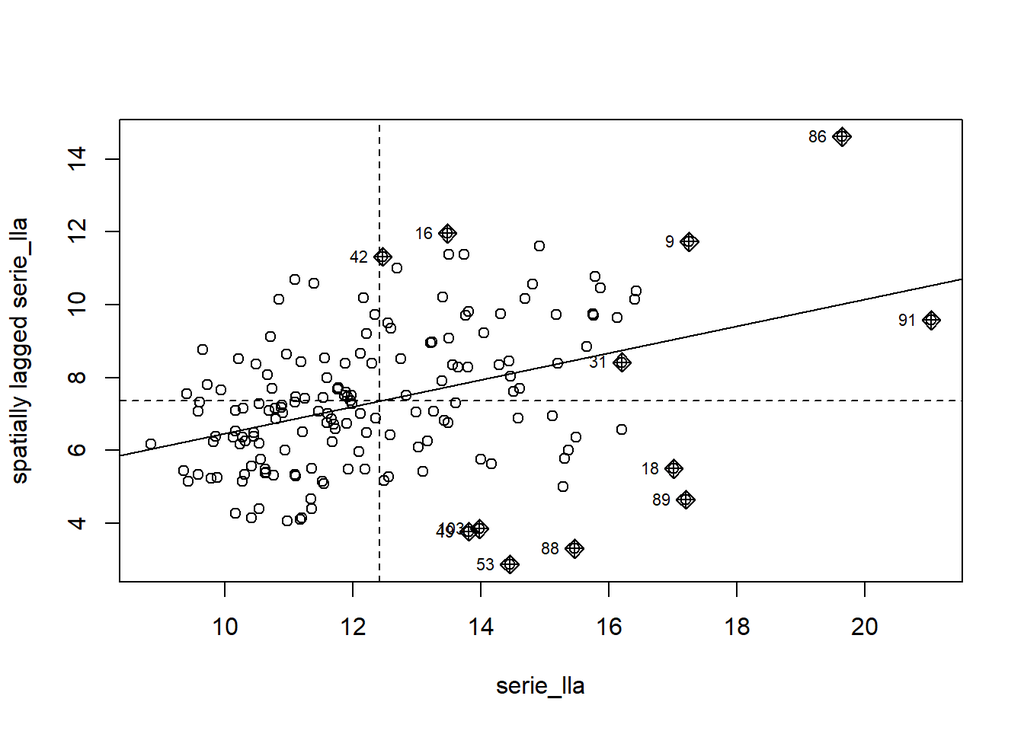

```r
moran_df <- moran.plot(serie_lla,
                       listw = pesos,
                       zero.policy = TRUE,
                       labels = ids)
```

Las variables que nos interesan:

```r
moran_df %>%
  select(x, wx, labels) %>%
  head()
```

```
         x       wx labels
1 11.72315 6.590744      1
2 12.18267 5.481422      2
3 16.12327 9.639230      3
4 13.38411 7.904996      4
5 15.75678 9.714773      5
6 11.69868 6.709692      6
```

## 4.5. Medida local: LISA

Para considerar la heterogeneidad especial podemos hacer uso de índices de asociación espacial locales. En el caso del índice I de Moran, existe su versión desagregada para analizar cómo varía la relación entre cada punto y sus vecinos.

```r
i_moran_local <- localmoran(serie_lla, listw = pesos)
i_moran_local <- cbind(i_moran_local,
                       attributes(i_moran_local)$quadr,
                       select(moran_df, x, wx, labels)) %>%
  rename(p = `Pr(z != E(Ii))`,
         cuadrante = mean) %>%
  select(x, wx, labels, Ii, p, cuadrante) %>%
  mutate(cuadrante_v2 = case_when(p > 0.05 ~ "ns",
                                  TRUE ~ cuadrante))

i_moran_local %>%
  head()
```

```
         x       wx labels          Ii            p cuadrante cuadrante_v2
1 11.72315 6.590744      1 -0.05886230 0.4189237240   Low-Low           ns
2 12.18267 5.481422      2 -0.02679140 0.2231919345   Low-Low           ns
3 16.12327 9.639230      3  0.77895560 0.0788784156 High-High           ns
4 13.38411 7.904996      4  0.36396646 0.0002997114 High-High    High-High
5 15.75678 9.714773      5  0.75790923 0.0588951901 High-High           ns
6 11.69868 6.709692      6 -0.07990713 0.2886135133   Low-Low           ns
```

```r
#pendiente: repetir diagrama de dispersión pero coloreando HH LL significativdad
# mapa coloreado para LLA
```

Las variables que nos interesan son las siguientes. - `Ii`: Valor del Moran local - `Pr(...)`: p-value del Moran local - `Cuadrante (mean)` : Cuadrante donde podemos clasificar el Moran local.

Repliquemos el gráfico anterior pero señalando los cuadrantes.

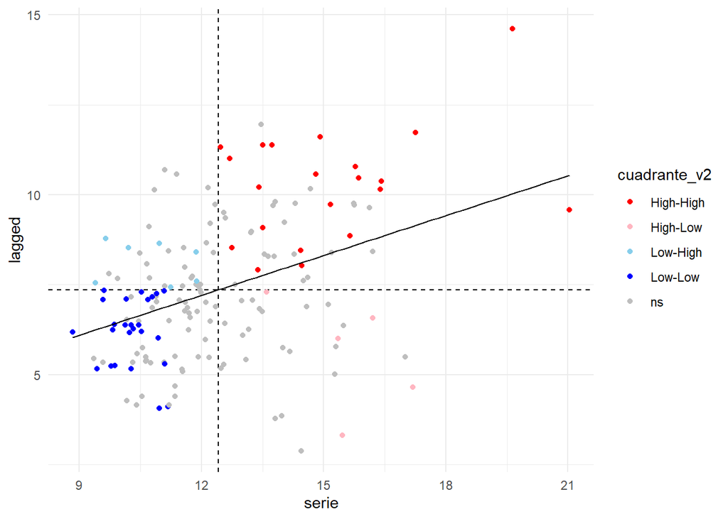

```r
nombres <- unique(i_moran_local$cuadrante_v2)
nombres <- c("ns","High-High", "High-Low","Low-High","Low-Low")
colores <- c("gray","red", "lightpink", "skyblue", "blue")
names(colores) <- nombres

i_moran_local %>%
  ggplot(aes(x=x, y=wx))+
  geom_hline(linetype = 2, yintercept = mean(i_moran_local$wx)) +
  geom_vline(linetype = 2, xintercept = mean(i_moran_local$x)) +
  geom_point(aes(color=cuadrante_v2))+
  geom_smooth(method="lm", se=F, color="black", linewidth=.5)+
  scale_color_manual(values=colores)+
  labs(x="serie", y="lagged")+
  theme_minimal()
```

¿Cómo lo incorporamos al análisis?

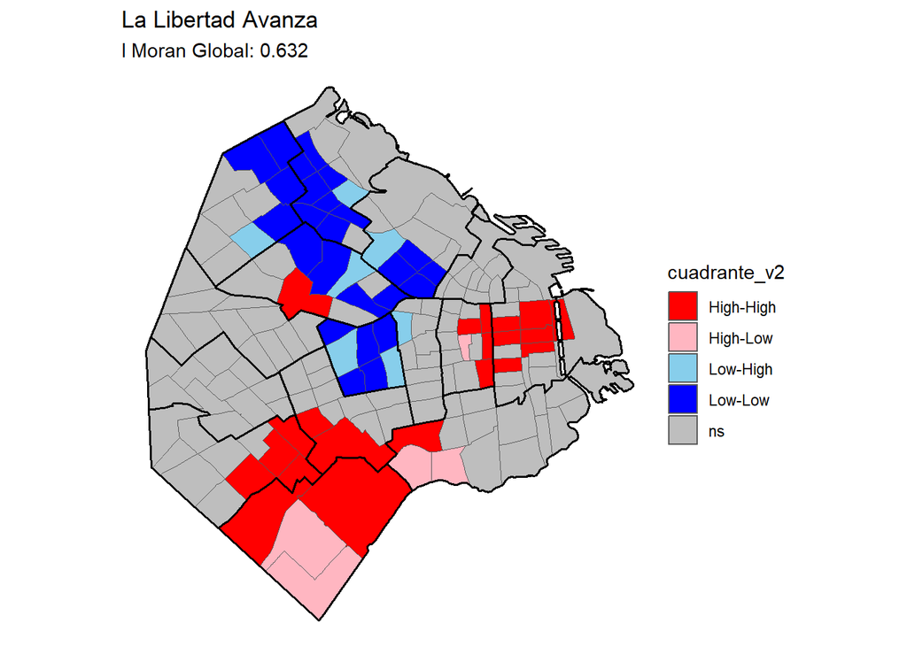

```r
i_moran_local_short <- i_moran_local %>% select(labels, cuadrante_v2)

plot_lla <- gdf_w %>%
  left_join(i_moran_local_short, by=c("circuito" =  "labels")) %>%
  ggplot()+
  geom_sf(aes(fill=cuadrante_v2))+
  geom_sf(data=sec, color="black", fill=NaN, linewidth=.7)+
  scale_fill_manual(values=colores)+
  labs(title="La Libertad Avanza",
       subtitle=paste0("I Moran Global: ", round(i_moran,3)))+
  theme_void()

plot_lla
```

Replicamos para el resto de los partidos.

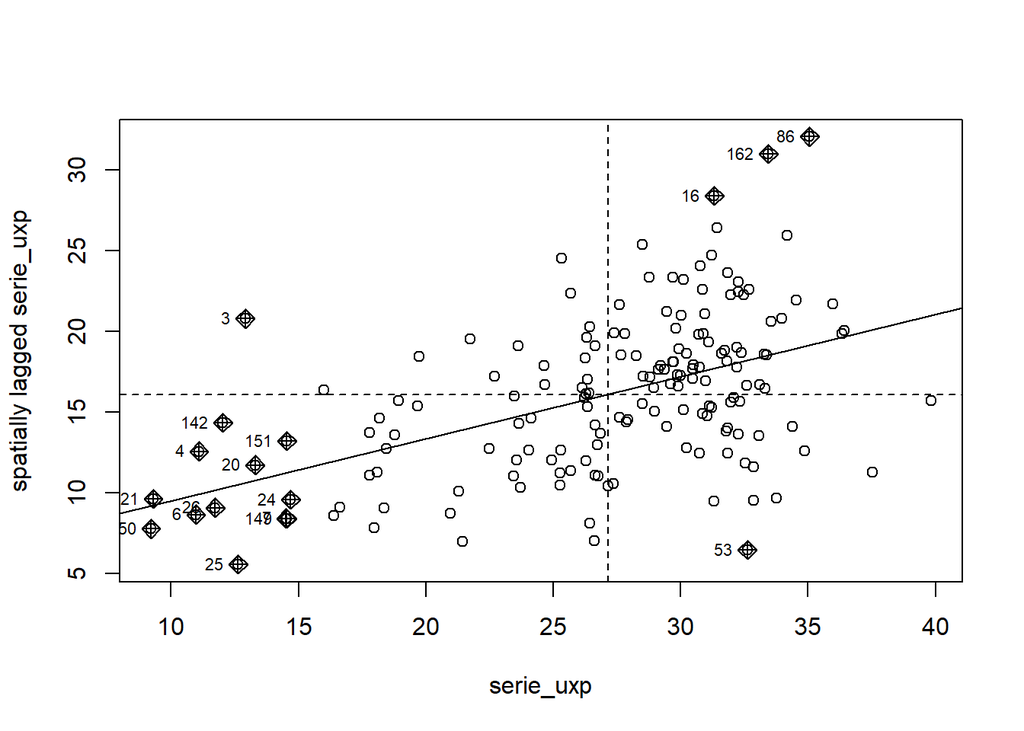

```r
serie_uxp <- gdf_w$`union por la patria`
serie_jxc <- gdf_w$`juntos por el cambio`

# moran global
mg_uxp <- moran(serie_uxp, n = length(vecinos),listw = pesos, S0 = Szero(pesos))[[1]]
mg_jxc <- moran(serie_jxc, n = length(vecinos),listw = pesos, S0 = Szero(pesos))[[1]]

# x, wx, labels
mdf_uxp <- moran.plot(serie_uxp, listw = pesos, zero.policy = TRUE, labels = ids)
```

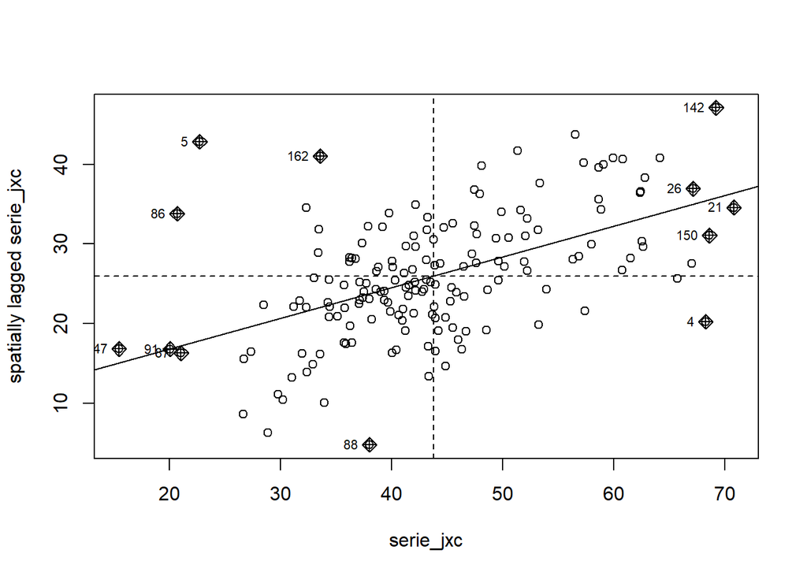

```r
mdf_jxc <- moran.plot(serie_jxc, listw = pesos, zero.policy = TRUE, labels = ids)
```

```r
# moran local
ml_uxp <- localmoran(serie_uxp, listw = pesos)
ml_uxp <- cbind(ml_uxp, attributes(ml_uxp)$quadr,select(mdf_uxp, x, wx, labels)) %>%
  rename(p = `Pr(z != E(Ii))`,
         cuadrante = mean) %>%
  select(x, wx, labels, Ii, p, cuadrante) %>%
  mutate(cuadrante_v2 = case_when(p > 0.05 ~ "ns",TRUE ~ cuadrante))

ml_jxc <- localmoran(serie_jxc, listw = pesos)
ml_jxc <- cbind(ml_jxc, attributes(ml_jxc)$quadr,select(mdf_jxc, x, wx, labels)) %>%
  rename(p = `Pr(z != E(Ii))`,
         cuadrante = mean) %>%
  select(x, wx, labels, Ii, p, cuadrante) %>%
  mutate(cuadrante_v2 = case_when(p > 0.05 ~ "ns",TRUE ~ cuadrante))

# short
ml_uxp_short <- ml_uxp %>% select(labels, cuadrante_v2)
ml_jxc_short <- ml_jxc %>% select(labels, cuadrante_v2)

plot_uxp <- gdf_w %>%
  left_join(ml_uxp_short, by=c("circuito" =  "labels")) %>%
  ggplot()+
  geom_sf(aes(fill=cuadrante_v2))+
  geom_sf(data=sec, color="black", fill=NaN, linewidth=.7)+
  scale_fill_manual(values=colores)+
  labs(title="Unión por la Patria",
       subtitle=paste0("I Moran Global: ", round(mg_uxp,3)))+
  theme_void()

plot_jxc <- gdf_w %>%
  left_join(ml_jxc_short, by=c("circuito" =  "labels")) %>%
  ggplot()+
  geom_sf(aes(fill=cuadrante_v2))+
  geom_sf(data=sec, color="black", fill=NaN, linewidth=.7)+
  scale_fill_manual(values=colores)+
  labs(title="Juntos por el Cambio",
       subtitle=paste0("I Moran Global: ", round(mg_jxc,3)))+
  theme_void()
```

Veamos comparativamente las tres fuerzas. Primero los resultados, después su autocorrelación espacial.

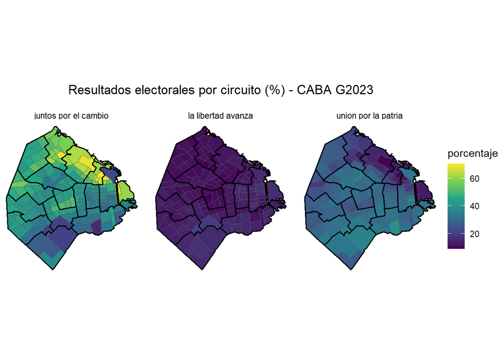

```r
partidos <- c("la libertad avanza", "union por la patria", "juntos por el cambio")
gdf %>%
  filter(partido %in% partidos) %>%
  ggplot()+
  geom_sf(aes(fill=porcentaje)) +
  geom_sf(data=sec, color="black", fill=NaN, linewidth=.7)+
  scale_fill_viridis_c()+
  facet_wrap(~partido)+
  labs(title="Resultados electorales por circuito (%) - CABA G2023\n")+
  theme_void()+
  theme(plot.title = element_text(hjust=0.5))
```

Las escalas diferenciadas complican la lectura. Normalicemos desde los datos para poder aplicar el facetado.

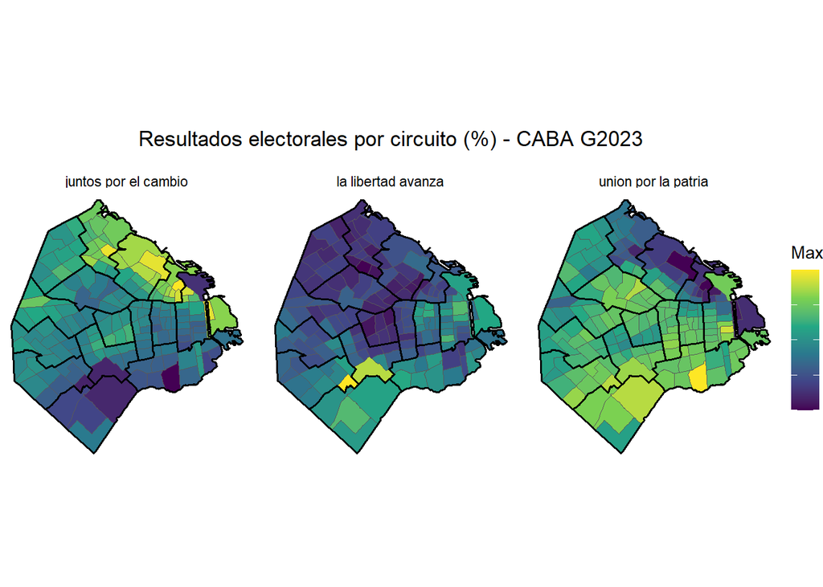

```r
gdf %>%
  filter(partido %in% partidos) %>%
  group_by(partido) %>%
  mutate(porcentaje_norm=(porcentaje - min(porcentaje)) / (max(porcentaje)-min(porcentaje)) ) %>%
  ungroup() %>%
  ggplot()+
  geom_sf(aes(fill=porcentaje_norm)) +
  geom_sf(data=sec, color="black", fill=NaN, linewidth=.7)+
  scale_fill_viridis_c()+
  facet_wrap(~partido)+
  labs(title="Resultados electorales por circuito (%) - CABA G2023\n",
       fill="Max")+
  theme_void()+
  theme(plot.title = element_text(hjust=0.5),
        legend.text = element_blank())
```

Finalmente, vemos los cuadrantes.

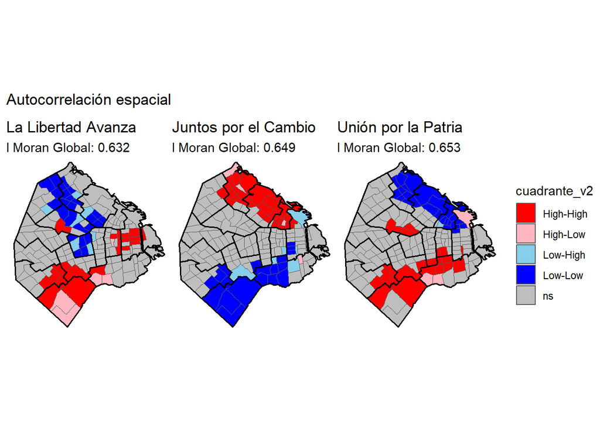

```r
(plot_lla + plot_jxc + plot_uxp)+
  plot_layout(guides="collect", ncol=3)+
  plot_annotation(title="Autocorrelación espacial")
```

## 🧪 Práctica (15 minutos)

- Calcular el índice I de Moran Local para LLA en el año 2025. Analizar los patrones geográficos del voto a La Libertad Avanza en el año 2023 y en el año 2025. ¿Qué pueden decir al respecto?